| 语言 / Language | 版本 |
| --- | --- |
| 🇨🇳 中文 | README.zh-CN.md |
| 🇺🇸 English | README.md |

# chinacolor :中国传统色

## ✨ 最新更新

### v0.1.0 (2025-10-05)

**新功能**

- 新增 `monochromatic_palette()`,`analogous_palette()`等10个自动生成调色板的函数；
- `ctc_palette()`函数输出调色板与内置调色板一样，具备`palette type`属性；
- `scale_fill/color _ctc_c/d()`系列标度函数，支持带对应属性的定制调色板，极大丰富其适用性；

**功能增强**

- 优化了部分连续型和发散性内置调色板,删除了部分调色板，新增了部分调色板，各类型数量未发生变化
- 优化了`theme_ctc_*()`系列函数内容，增加了theme选项

**问题修复**

- 修复了chinacolor 颜色基础数据汇总RGB值的错误
- 调整了`plot_palette()`函数颜色值及中文名称的字体大小

### 后续更新计划

- 从应用场景、行业属性等角度增加调色板及theme功能，如期刊发表，日常办公，客户导向等维度
- 机器学习与色彩理论、色彩心理学、配色原理等结合获得色彩心理模型，用于基于情绪及实物场景的配色方案生成

以下是包含更新内容介绍材料

受中文书籍[《中国传统色：故宫里的色彩美学》](https://baike.baidu.com/item/%E4%B8%AD%E5%9B%BD%E4%BC%A0%E7%BB%9F%E8%89%B2%EF%BC%9A%E6%95%85%E5%AE%AB%E9%87%8C%E7%9A%84%E8%89%B2%E5%BD%A9%E7%BE%8E%E5%AD%A6/56817070)的启发制作本包，将该书中384种颜色关键信息整理成颜色数据信息，基于这些数据：

- 内置了顺序型、发散性和定性型调色板各20个；
- 内置了5款基于中国传统文化特色的适配ggplot的绘图主题；
- 形成了浏览、打印这些颜色和调色板的函数，快速获取颜色和调色板信息；
- 形成了利用这些颜色或内置调色板定制调色板的工具；
- **形成了根据需求定制调色板的系列函数，并将输出应用于scales系列函数；**
- 形成了适配ggplot绘图的scales系列函数。

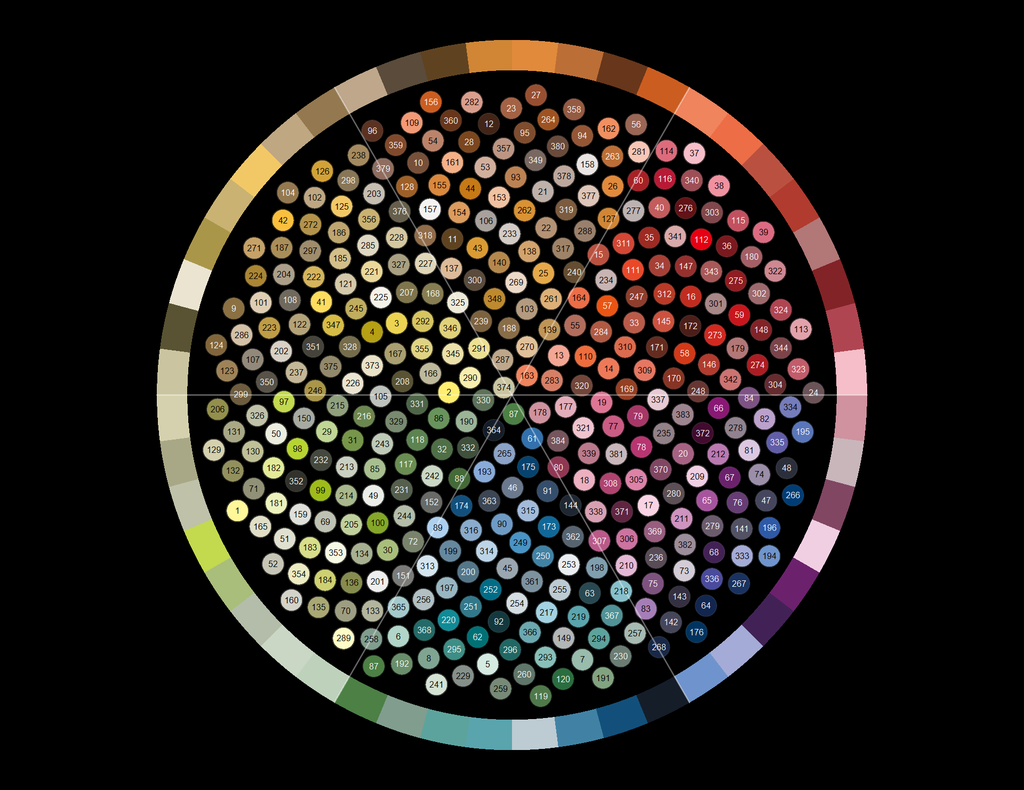

颜色图形

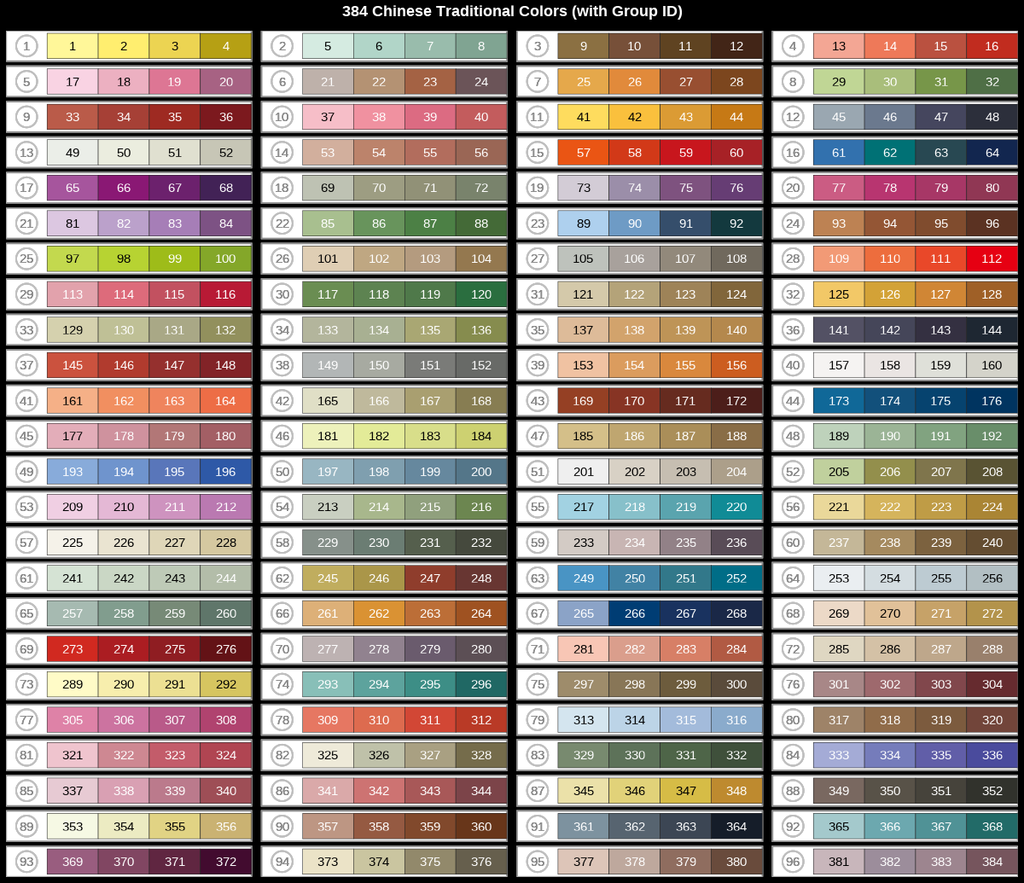

带颜色分组编码的全部384种颜色

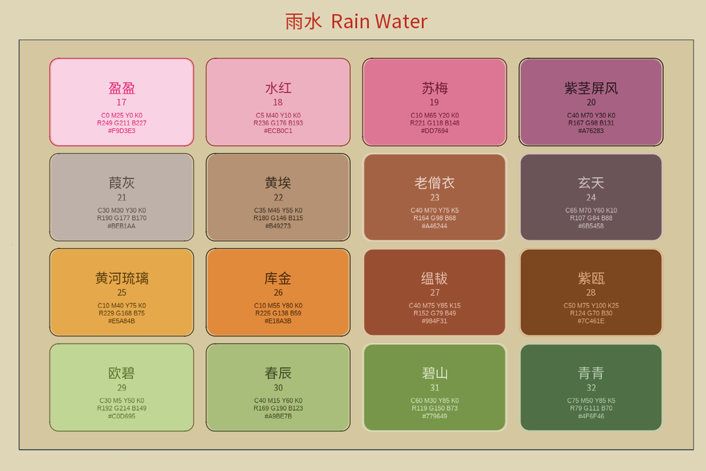

按节气分组的颜色

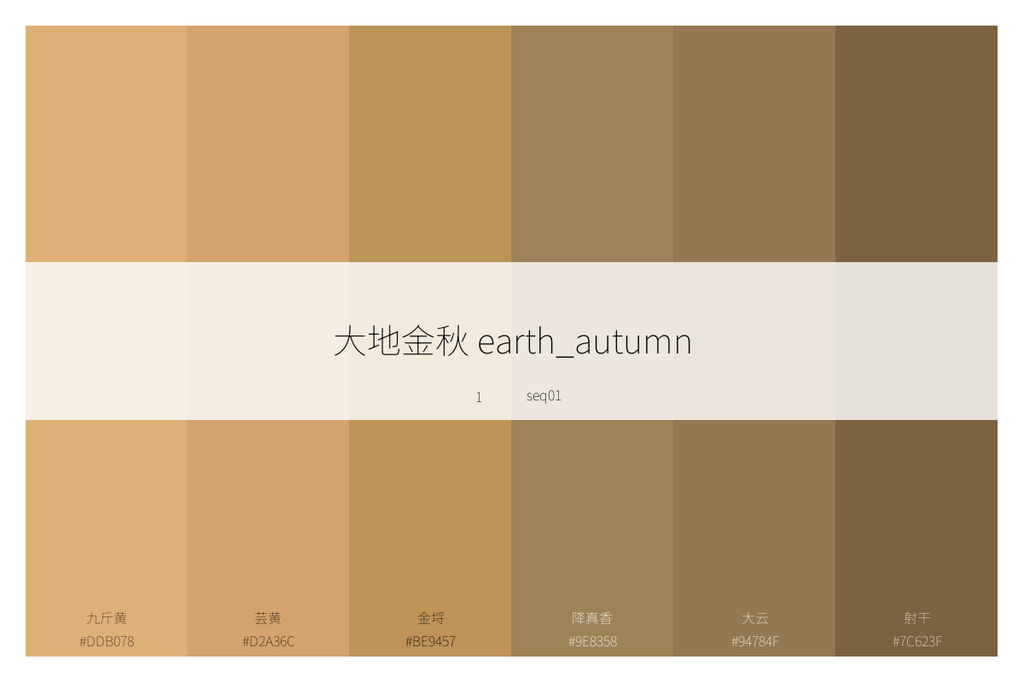

调色板示例

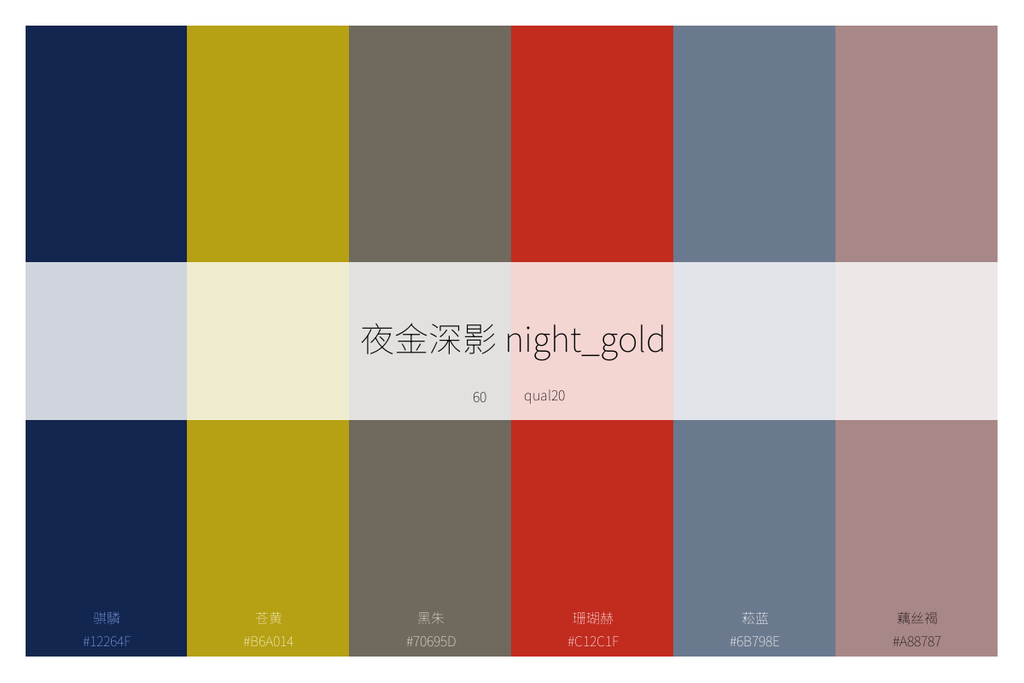

调色板示例

## 安装

用如下方法安装本包开发版。

```r
 # 用 devtools 安装
devtools::install_github("zhiming-chen/chinacolor")

# 或用 remotes 安装（语法相同）
remotes::install_github("zhiming-chen/chinacolor")
```

## 颜色:打印、预览与获取

### plot_color_grid 打印全部颜色

```r
plot_color_grid(show_group = T)
```

可以在colors_by_solar_term 中查看全部24个节气的颜色系列。

### list_colors 快速预览颜色

`list_colors`函数实现在Rstudio 中Viewer界面快速预览颜色，并即时获得颜色hex值，这个功能在我们设计调色板，或者绘图时调整颜色时提供帮助。

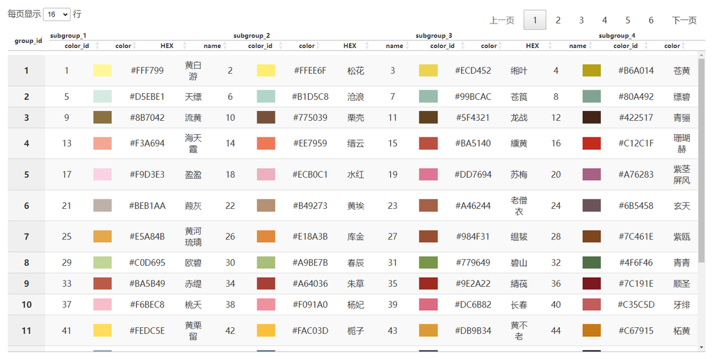

```r
list_colors()
```

## 调色板：打印、预览、获取与定制

60组调色板被预置于本包中供调用。几个调色板示例：

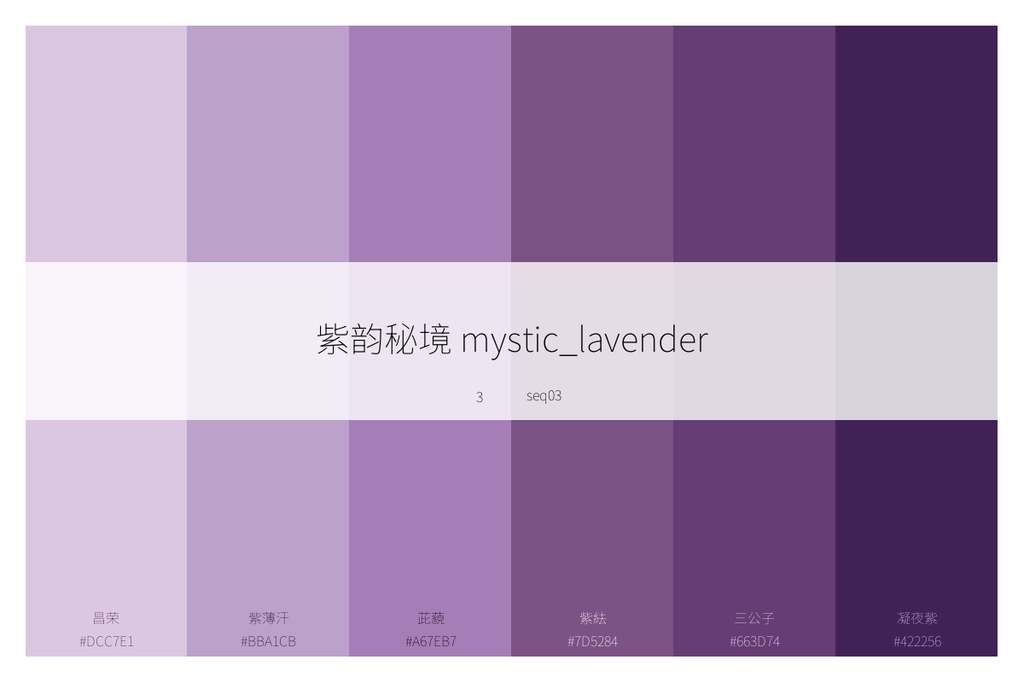

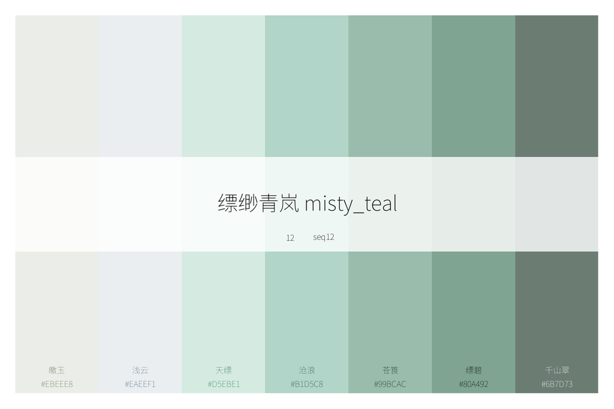

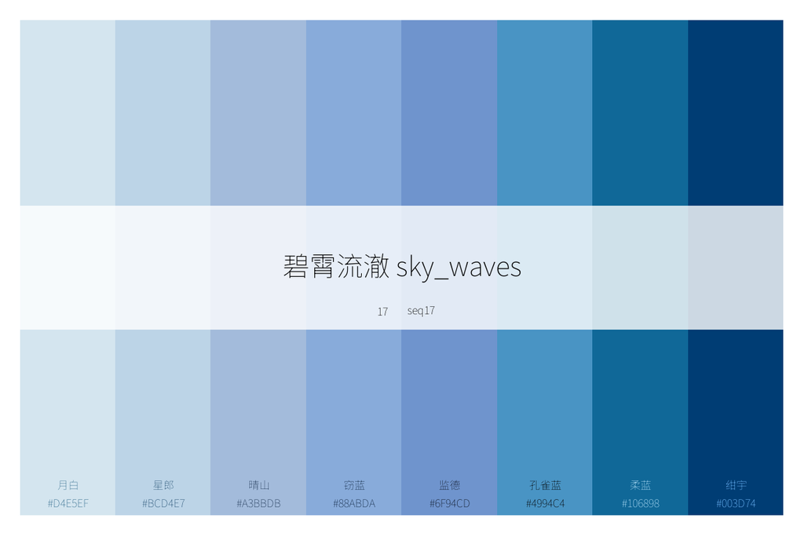

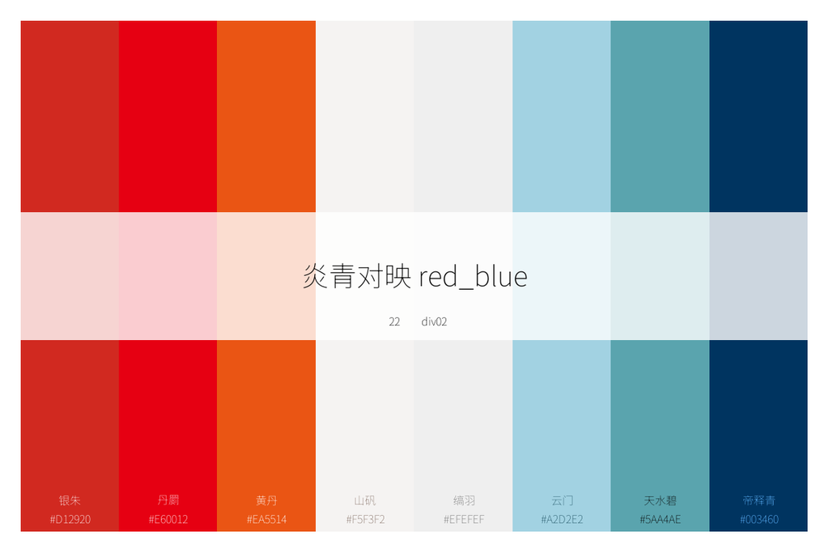

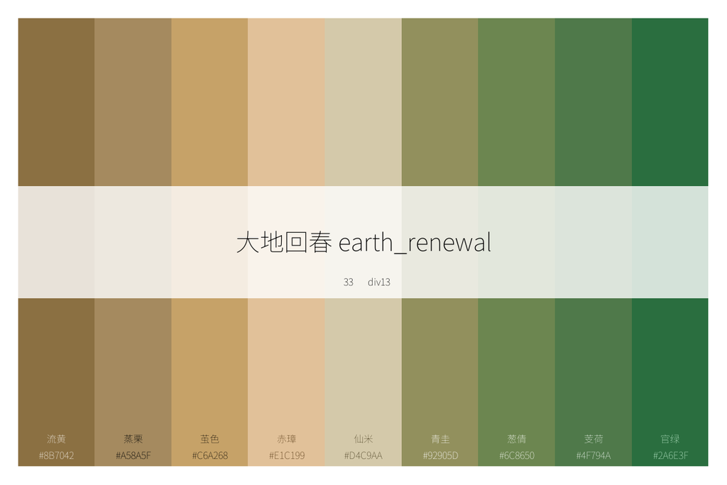

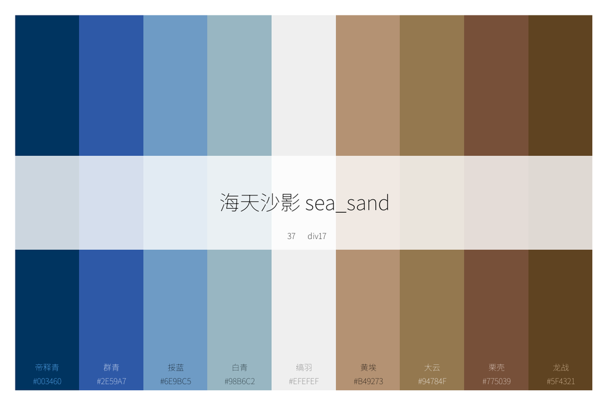

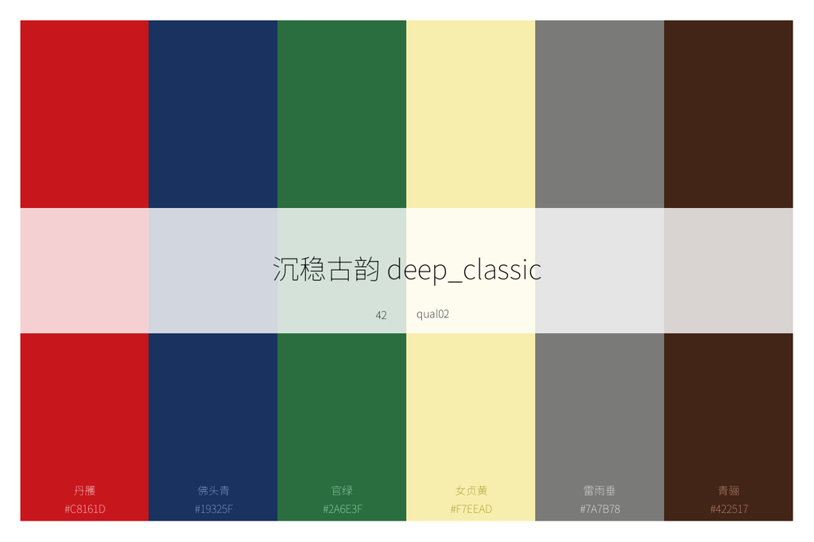

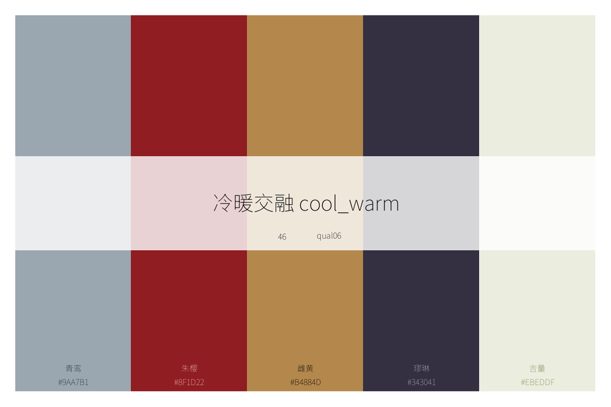

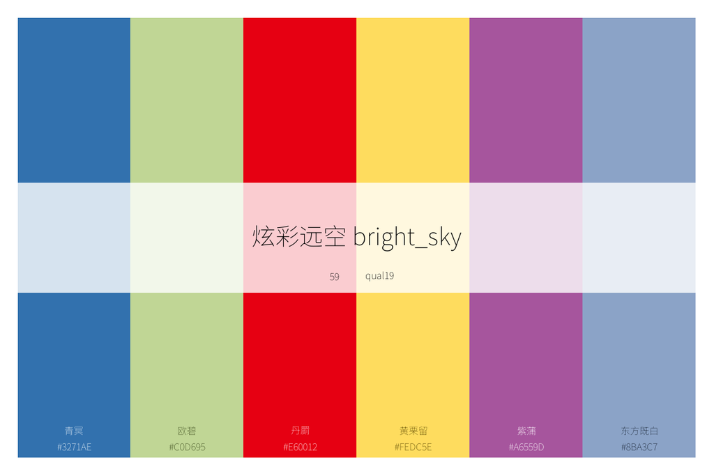

内置的调色板被定义为三种类型，顺序型，发散型和定性型。每种20个。

这些调色板被id化以及规则命名化：

- 顺序型调色板：
  - id：1-20
  - 命名：seq01-seq20。
- 发散型调色板：
  - id：21-40
  - 命名：div01-div20。
- 定性型调色板：
  - id：41-60
  - 命名：qual01-qual20。

当然，每个调色板也有其中文名称与英文名称，通过输入对应名称，可获取单个调色板信息。

### list_palettes 预览调色板

和预览颜色一样，调色板也可以在Viewer界面进行预览。

[figure not shown]

```r
list_palettes()
```

我们还可以通过这个函数将这些内置调色板信息导出。

```r
palettes_info <- list_palettes()

head(palettes_info,10)
```

```
#>       Index ElementName ChineseName     EnglishName       Type Colors
#> seq01     1       seq01    大地金秋    earth_autumn sequential      6
#> seq02     2       seq02    绯色年华  blooming_blush sequential      6
#> seq03     3       seq03    紫韵秘境 mystic_lavender sequential      6
#> seq04     4       seq04    珊瑚暖绯    coral_warmth sequential      7
#> seq05     5       seq05    幽兰绀紫   mystic_purple sequential      7
#> seq06     6       seq06    金秋丰韵  golden_harvest sequential      9
#> seq07     7       seq07    橘暖时光       warm_glow sequential      7
#> seq08     8       seq08    琥珀大地     amber_earth sequential      7
#> seq09     9       seq09    林间雾色     forest_mist sequential      6
#> seq10    10       seq10    琥珀流光      amber_glow sequential      7
```

### plot_palettes 打印多个调色板

`plot_palettes` 函数支持将多个调色板打印在一张图上，实现调色板的比较和选择。支持index和元素名称输入。

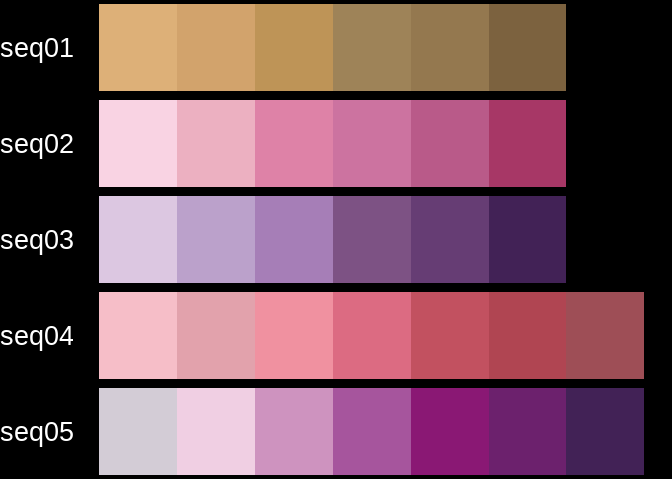

```r
# 通过index值打印
plot_palettes(1:5)
```

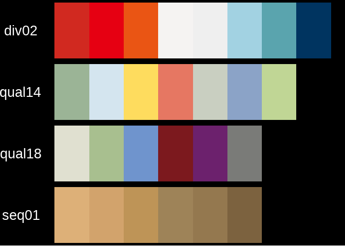

```r
# 通过元素名称打印
plot_palettes(c("seq01","div02","qual14","qual18"))
```

### plot_palette 打印单个调色板

这个函数打印内置的调色板，也支持打印自定义的调色板。默认模式为内置调色板。

当打印内置调色板时，支持index，元素名称，及调色板的中英文名称作为输入。

- 打印内置调色板

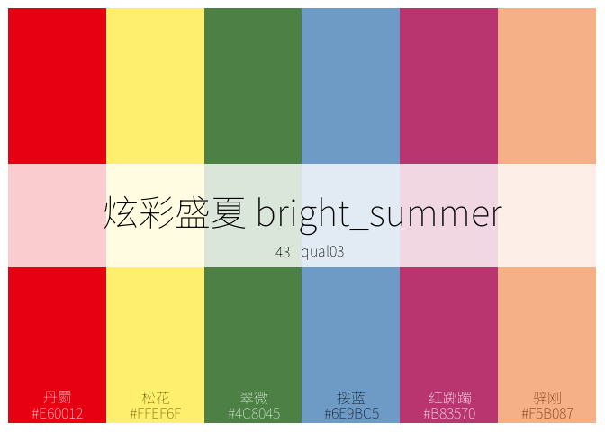

```r
# 根据index打印
plot_palette(x = 43,show_text = T)
```

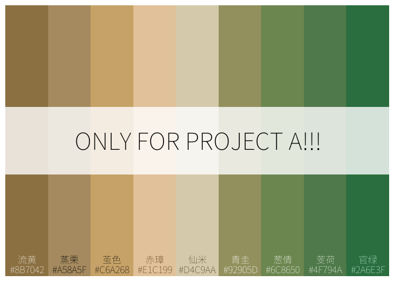

```r
# 根据元素名称打印，并对调色板进行重命名

plot_palette(x = "div13",name = "ONLY FOR PROJECT A!!!",show_text = T)
```

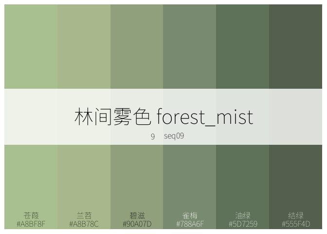

```r
# 根据调色板英文名打印，显示颜色信息

plot_palette(x = "forest_mist",show_text = T)
```

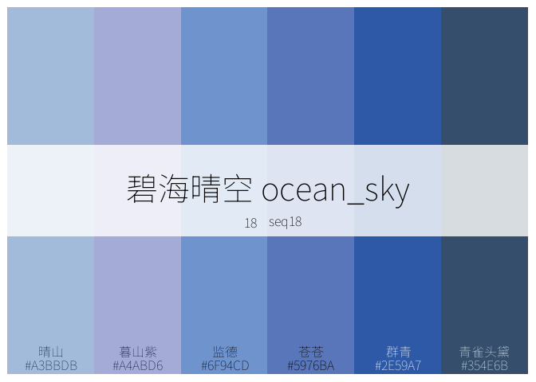

```r
# 根据调色板中文名打印，显示颜色信息
plot_palette(x = "碧海晴空",show_text = T)
```

对于内置调色板，打印图形中间条形块内显示了关于调色板的四个信息，以帮助大家进行快速记忆与选择。底部可现实颜色hex值及其中文名称。出于显示效果考虑，函数将该参数设置为非默认显示。

- 打印自定义调色板

对于自定义调色板，输入可以是颜色向量或向量对象名称。

对于来自384种内置的颜色，支持显示中文名。

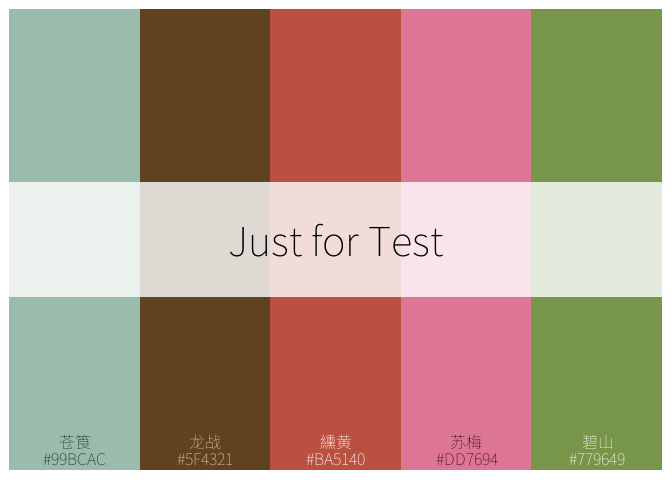

```r
# 设置调色板名称
plot_palette(x = c("#99BCAC","#5F4321","#BA5140","#DD7694","#779649"),type = "custom",name = "Just for Test",show_text = T)
```

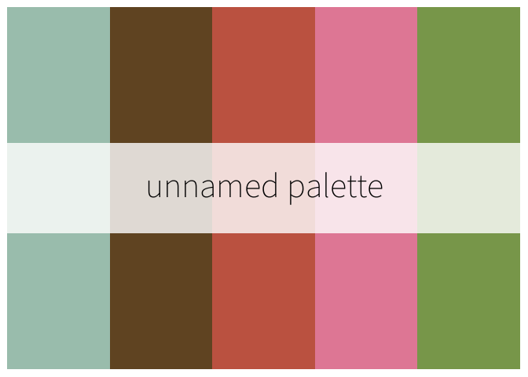

```r
# 未设置调色板名称。不显示颜色信息
plot_palette(x = c("#99BCAC","#5F4321","#BA5140","#DD7694","#779649"),type = "custom")
```

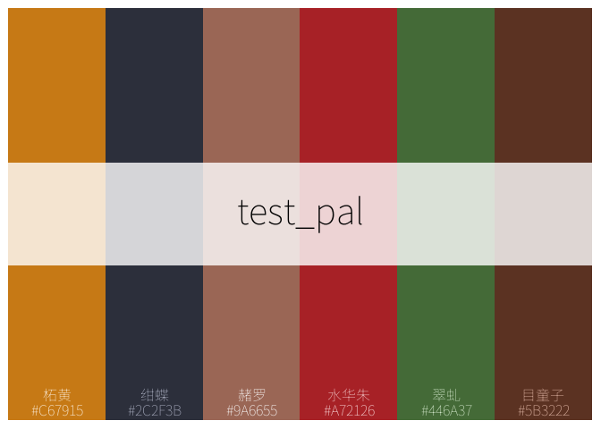

```r
# 输入向量名,调色板的名称将是向量名

test_pal <- c("#C67915","#2C2F3B","#9A6655","#A72126","#446A37","#5B3222")
plot_palette(x = test_pal,type = "custom",show_text = T)
```